# PS 641 - Bivariate Regression

Robert Durbin and Prof Kuehl

October 09, 2025

Packages

```r
library(dplyr)
```

```r
library(ggplot2)
```

Load the traffic data(traffic.RData. Note we are using a Rproject this week so don’t need to set our working directory.

```r
load("traffic.rdata")
```

Here’s a Codebook:

[output not shown]

Explore the data:

```r
table(traffic$year)
```

```
##
## 2010 2011 2012 2013 2014 2015 2016 2017 2018 2019
##  102  102  102  102  102  102  102  102  102  102
```

```r
# Subset for the year 2019
traffic2019 <- subset(traffic, year == "2019")
```

Lets look at the relationship between the population of a county and its number of traffic fatalities.

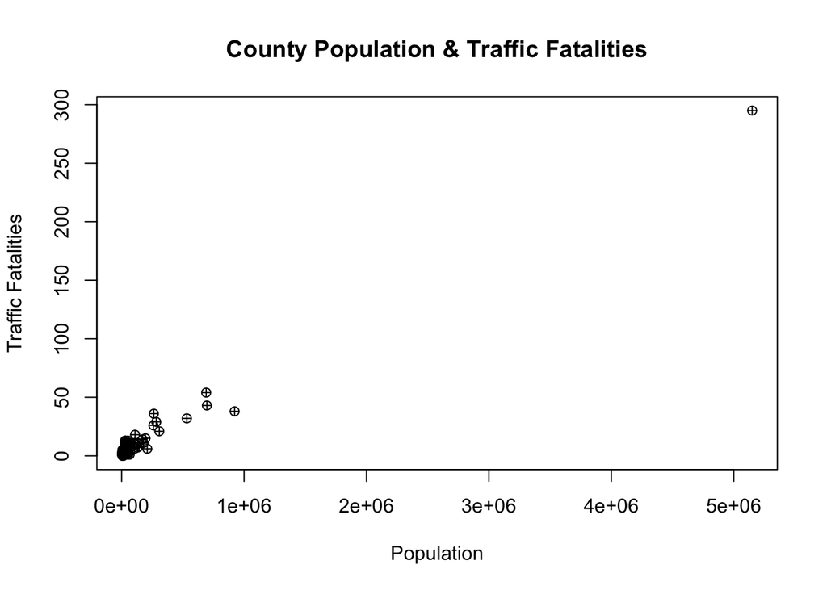

```r
plot(traffic2019$pop, traffic2019$deaths,xlab="Population", ylab="Traffic Fatalities", main="County Population & Traffic Fatalities", pch=10) #creates a scatterplot
```

```r
#What type of relationship does this look like? What terms could we use to describe it? What is the outlier and what should we do about it.
```

We can also run this plot without Cook County as an outlier, making it easier to see the trend.

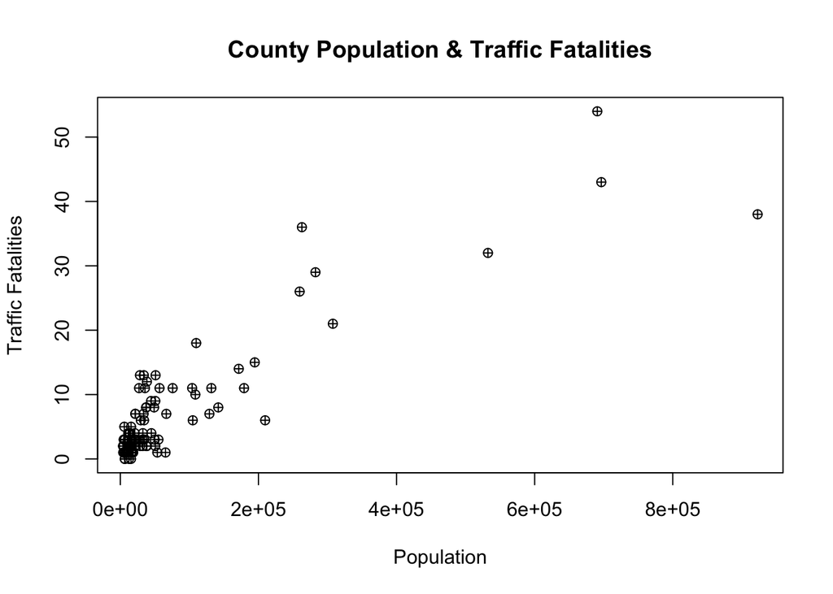

```r
# Filter out rows where county is "Cook"
traffic_filtered <- traffic2019[traffic2019$county != "Cook",]

plot(traffic_filtered$pop, traffic_filtered$deaths,xlab="Population", ylab="Traffic Fatalities", main="County Population & Traffic Fatalities", pch=10) #creates a scatterplot
```

```r
#What type of relationship does this look like? What terms could we use to descripte it?
```

```r
#To standardize measures let's create a per capita measure for some of our variables)

traffic2019$percapdeaths <- traffic2019$deaths/traffic2019$pop * 100000 # This command creates per capita deaths from traffic fatalities and multiplies it by 100,000 as deaths per 100,000 is the standard reporting metric for this data.

summary(traffic2019$percapdeaths)
```

```
##    Min. 1st Qu.  Median    Mean 3rd Qu.    Max.
##    0.00    6.54   12.87   16.91   21.03   86.79
```

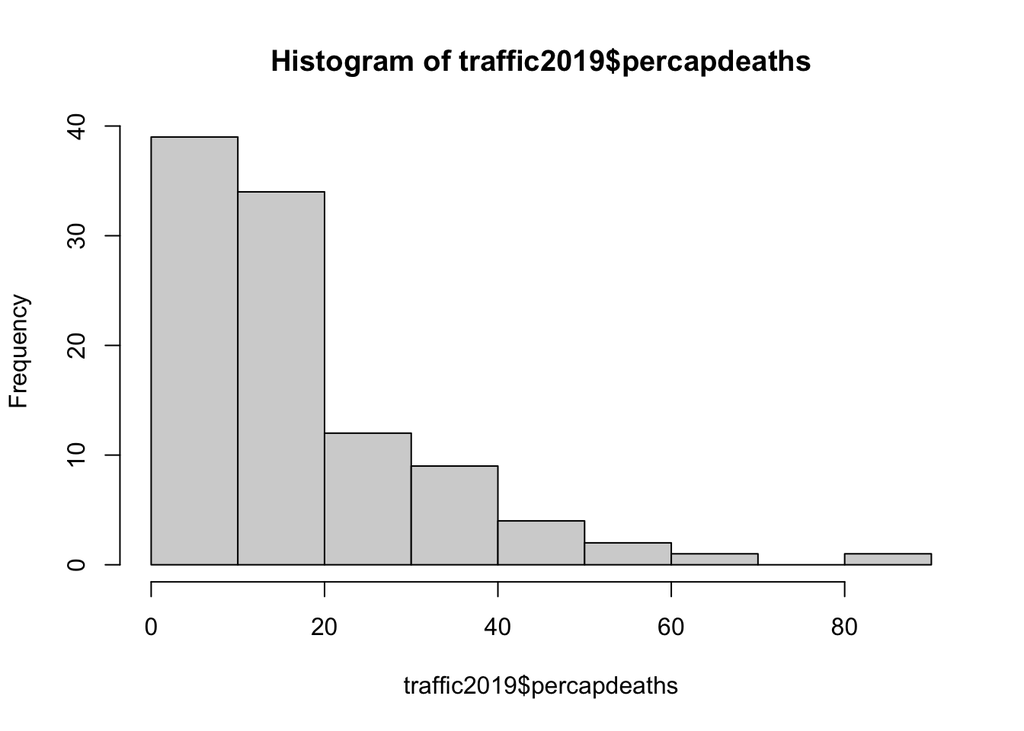

```r
hist(traffic2019$percapdeaths)
```

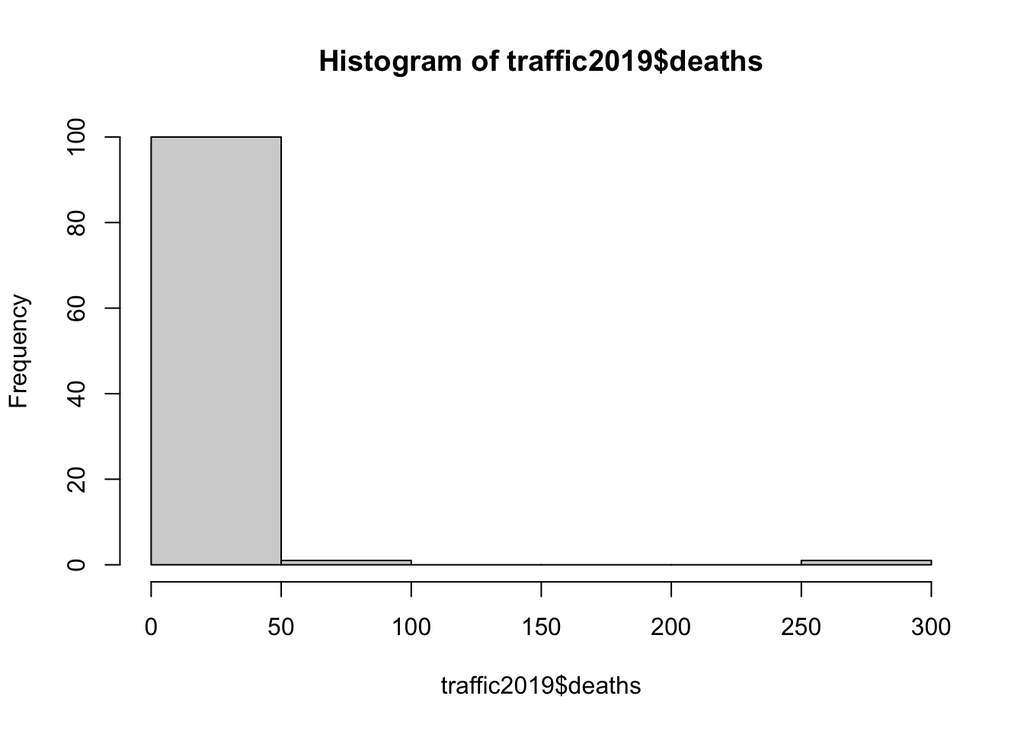

```r
hist(traffic2019$deaths)#shows importance of using per capita
```

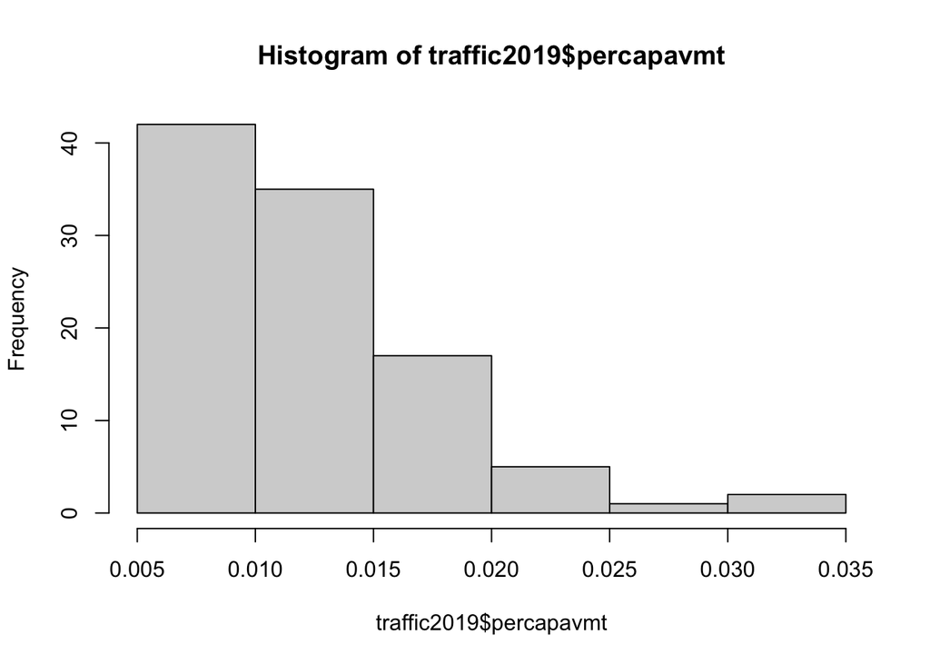

```r
traffic2019$percapavmt <- round((traffic2019$avmt/traffic2019$pop)/1000000, 9) # The "round" command...you guessed it, rounds the resulting percapavmt variable(usually we only round when reporting results). This creates a per capita measure of annual vehicle miles traveled divided by one million, again as this is the usual metric for working with this sort of data.

hist(traffic2019$percapavmt)
```

First tests of association

```r
cov(traffic2019$pop, traffic2019$deaths) #Covariance, in isolation can't interpret much more than sign
```

```
## [1] 15556660
```

```r
cor(traffic2019$pop, traffic2019$deaths) #Correlation, range from -1 to 1. Note: There is no defined rule as to when variables are significant or not. The farther from 0 the greater the relationship.
```

```
## [1] 0.9896161
```

Can create correlation matrix with select variables. This is a good way to get a glimpse (start thinking about) the relationships between lots of variables.

```r
traffic2 <- select(traffic2019, percapdeaths, percapavmt, income, popden, female)
cor(traffic2)
```

```
##              percapdeaths   percapavmt      income     popden       female
## percapdeaths    1.0000000  0.302107748 -0.34185943 -0.1804911  0.137118205
## percapavmt      0.3021077  1.000000000 -0.17329297 -0.2125489 -0.008598372
## income         -0.3418594 -0.173292971  1.00000000  0.3352851  0.039283557
## popden         -0.1804911 -0.212548876  0.33528514  1.0000000  0.125283553
## female          0.1371182 -0.008598372  0.03928356  0.1252836  1.000000000
```

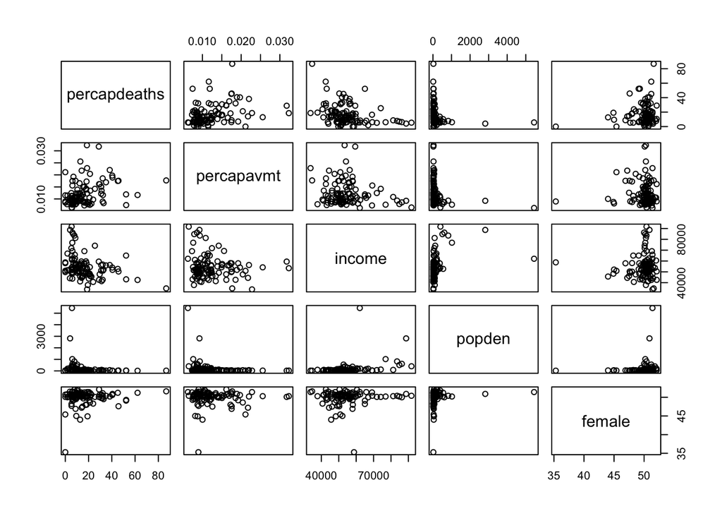

```r
pairs(traffic2) #Gives a quick look graphically(numbers far more useful)
```

#Regression - woooohooooo Lets look at the relationship between Annual Vehicle Miles Travelled (avmt) and Traffic Fatalities (deaths)

Our model: Per Capita Traffic Fatalities = $\beta_0$ + $\beta_1$ Per Capita Annual Vehicle Miles Travelled + e

```r
model1 <- lm(percapdeaths ~ percapavmt, data = traffic2019) #creates a regression model. lm = linear model. the "<-"creates an object that simplifies later steps.

summary(model1) #What does this output tell us? ie how do we interpret the coefficients and p-values? Is the relationship statistically significant?
```

```
##
## Call:
## lm(formula = percapdeaths ~ percapavmt, data = traffic2019)
##
## Residuals:
##     Min      1Q  Median      3Q     Max
## -24.475  -7.810  -3.604   6.264  65.300
##
## Coefficients:
##             Estimate Std. Error t value Pr(>|t|)
## (Intercept)    6.088      3.676   1.656  0.10087
## percapavmt   870.564    274.699   3.169  0.00203 **
## ---
## Signif. codes:  0 '***' 0.001 '**' 0.01 '*' 0.05 '.' 0.1 ' ' 1
##
## Residual standard error: 13.76 on 100 degrees of freedom
## Multiple R-squared:  0.09127,    Adjusted R-squared:  0.08218
## F-statistic: 10.04 on 1 and 100 DF,  p-value: 0.002029
```

Significance P-value: 0.00203 - statistically significant at .01 level

Sign Estimate: Positive

Size Estimate: 870.564; A one unit increase in the annual vehicle miles (percapavmt) traveled in a county is associated with an additional 871 units in percapdeaths (which we have multiplied by 100,000).

Substantive: an annual increase of one million vehicle miles traveled is associated with 0.00871 more traffic fatalities. (alternatively) For every 115 million miles driven we expect one traffic fatality.

(The United States had more than 3.26 trillion annual vehicle miles traveled in 2022 according to the Department of Energy, so assuming the rate for Illinois in 2019 was roughly the same as it was nationwide, we would expect 28,348 traffic fatalities in 2022. We actually had 42,795.)

Now we can show it graphically(This looks familiar . . . . .)

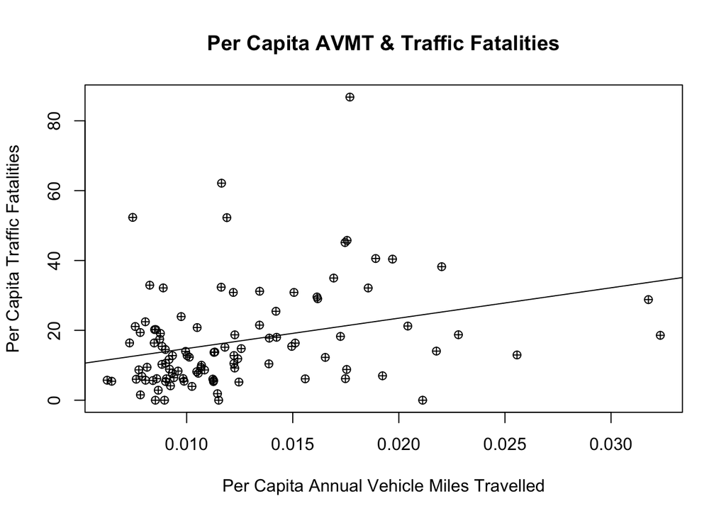

```r
plot(traffic2019$percapavmt, traffic2019$percapdeaths, xlab = "Per Capita Annual Vehicle Miles Travelled", ylab = "Per Capita Traffic Fatalities", main = "Per Capita AVMT & Traffic Fatalities", pch=10) #creates a scatterplot
abline(model1) #puts the regression line onto our plot
```

Our Model: (Per Capita Traffic Deaths * 100,000) = $\beta_0$ + $\beta_1$ * (Per Capita AVMT/1,000,000) + e (Per Capita Traffic Deaths * 100,000) = 6.088 + 870.564 * (Per Capita AVMT/1,000,000) + e

Break: Is this causal?

Do it yourself Find a relationship you are interested in testing(use the codebook). Raise your hand when you’re ready to try to interpret it for the the class.(Yes, I’m serious)

```r
summary(lm(traffic2019$avmt ~ traffic2019$area))
```

```
##
## Call:
## lm(formula = traffic2019$avmt ~ traffic2019$area)
##
## Residuals:
##        Min         1Q     Median         3Q        Max
## -2.932e+09 -9.329e+08 -3.574e+08  1.099e+08  2.949e+10
##
## Coefficients:
##                    Estimate Std. Error t value Pr(>|t|)
## (Intercept)      -1.215e+09  8.551e+08  -1.421  0.15832
## traffic2019$area  4.171e+06  1.455e+06   2.868  0.00504 **
## ---
## Signif. codes:  0 '***' 0.001 '**' 0.01 '*' 0.05 '.' 0.1 ' ' 1
##
## Residual standard error: 3.262e+09 on 100 degrees of freedom
## Multiple R-squared:  0.07598,    Adjusted R-squared:  0.06674
## F-statistic: 8.223 on 1 and 100 DF,  p-value: 0.005045
```

```r
summary(lm(traffic2019$percapavmt ~ traffic2019$popden))
```

```
##
## Call:
## lm(formula = traffic2019$percapavmt ~ traffic2019$popden)
##
## Residuals:
##       Min        1Q    Median        3Q       Max
## -0.005586 -0.003517 -0.001360  0.002345  0.019625
##
## Coefficients:
##                      Estimate Std. Error t value Pr(>|t|)
## (Intercept)         1.275e-02  5.068e-04  25.159   <2e-16 ***
## traffic2019$popden -1.728e-06  7.945e-07  -2.175    0.032 *
## ---
## Signif. codes:  0 '***' 0.001 '**' 0.01 '*' 0.05 '.' 0.1 ' ' 1
##
## Residual standard error: 0.004896 on 100 degrees of freedom
## Multiple R-squared:  0.04518,    Adjusted R-squared:  0.03563
## F-statistic: 4.731 on 1 and 100 DF,  p-value: 0.03197
```

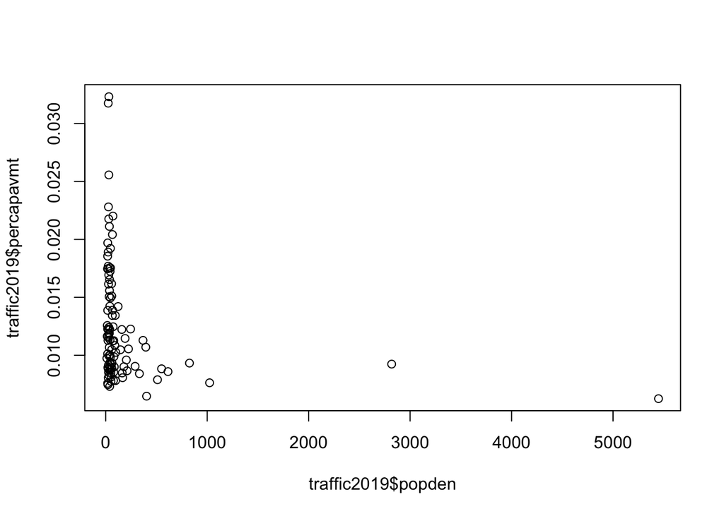

```r
plot(traffic2019$popden, traffic2019$percapavmt)
```

```r
summary(lm(traffic2019$percapdeaths ~ traffic2019$rain))
```

```
##
## Call:
## lm(formula = traffic2019$percapdeaths ~ traffic2019$rain)
##
## Residuals:
##     Min      1Q  Median      3Q     Max
## -24.845  -8.250  -3.857   4.799  62.930
##
## Coefficients:
##                  Estimate Std. Error t value Pr(>|t|)
## (Intercept)      -23.4158    16.0331  -1.460   0.1473
## traffic2019$rain   0.9849     0.3901   2.524   0.0132 *
## ---
## Signif. codes:  0 '***' 0.001 '**' 0.01 '*' 0.05 '.' 0.1 ' ' 1
##
## Residual standard error: 14 on 100 degrees of freedom
## Multiple R-squared:  0.05991,    Adjusted R-squared:  0.05051
## F-statistic: 6.373 on 1 and 100 DF,  p-value: 0.01316
```

Looking at it another way

```r
traffic2019$otherpercapavmt <- traffic2019$avmt/traffic2019$pop #This chunk exists solely because we are messing with the x axis label. To get the abline in the next bit of code to work we need to respecify the model from earlier but with the percapavmt variable similarly embiggened (arguably a word).



model2 <- lm(percapdeaths ~ otherpercapavmt, data = traffic2019) #creates a regression model. lm = linear model.

summary(lm(percapdeaths ~ otherpercapavmt, data = traffic2019)) #Does the same thing without creating an object
```

```
##
## Call:
## lm(formula = percapdeaths ~ otherpercapavmt, data = traffic2019)
##
## Residuals:
##     Min      1Q  Median      3Q     Max
## -24.475  -7.810  -3.604   6.264  65.300
##
## Coefficients:
##                  Estimate Std. Error t value Pr(>|t|)
## (Intercept)     6.0876227  3.6762499   1.656  0.10087
## otherpercapavmt 0.0008706  0.0002747   3.169  0.00203 **
## ---
## Signif. codes:  0 '***' 0.001 '**' 0.01 '*' 0.05 '.' 0.1 ' ' 1
##
## Residual standard error: 13.76 on 100 degrees of freedom
## Multiple R-squared:  0.09127,    Adjusted R-squared:  0.08218
## F-statistic: 10.04 on 1 and 100 DF,  p-value: 0.002029
```

Can add a confidence interval. It is often not necessary, but it helps us visualize the uncertainty of our estimates.

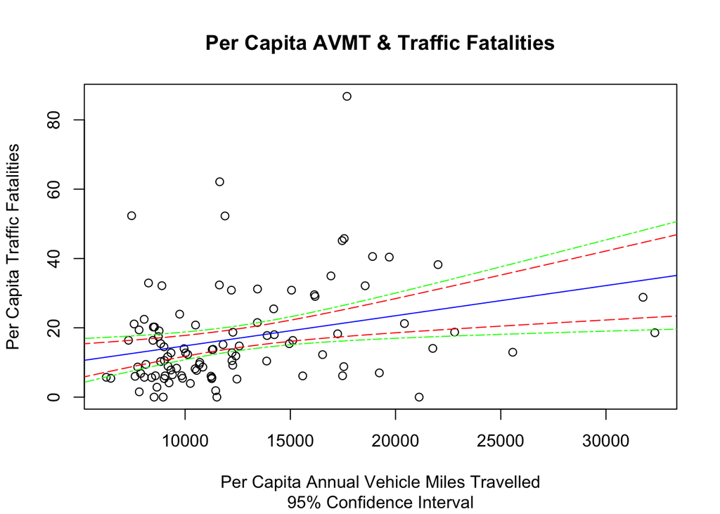

```r
plot((traffic2019$percapavmt*1000000), traffic2019$percapdeaths, xlab = "Per Capita Annual Vehicle Miles Travelled", ylab = "Per Capita Traffic Fatalities", main = "Per Capita AVMT & Traffic Fatalities", sub="95% Confidence Interval")  # To make this part of the analysis easier, we multiply the x axis by 1,000,000
abline(model2, pch=10, col="blue")


newx <- seq(5000, 35000, 1000) # creates sequence between .2 and .5 by .01 (Use your x-axis range for this)
a <- predict(model2, newdata = data.frame(otherpercapavmt = newx), interval = "confidence") #predicts values for sequence
lines(newx,a[,2], lty=5, col = "red") #add lines
lines(newx,a[,3], lty=5, col = "red")
#This shows the 95% confidence interval.

#### We can also see what a 99% confidence interval looks like.
b <- predict(model2, newdata=data.frame(otherpercapavmt=newx), interval="confidence", level=.99)
lines(newx,b[,2], lty=6, col="green")
lines(newx,b[,3], lty=6, col="green")
```

```r
#Why does the 99% have a larger confidence interval
```

We can then make predictions based on certain counties’ per capita AVMT:

```r
plot((traffic2019$percapavmt*1000000), traffic2019$percapdeaths, xlab = "Per Capita Annual Vehicle Miles Travelled", ylab = "Per Capita Traffic Fatalities", main = "Per Capita AVMT & Traffic Fatalities")
abline(model2, col="red", lwd = 2)
abline(v=8063.393, col="blue", lwd = 2) # Show prediction for Counties with Per Capita AVMT of 8063.393 (Number picked for no particular reason)

model2$fitted.values[which(traffic2019$percapavmt==0.008063393)] # Extract predictions
```

```
##       19
## 13.10732
```

```r
mean(model2$fitted.values[which(traffic2019$percapavmt==0.008063393)]) # Extract mean prediction
```

```
## [1] 13.10732
```

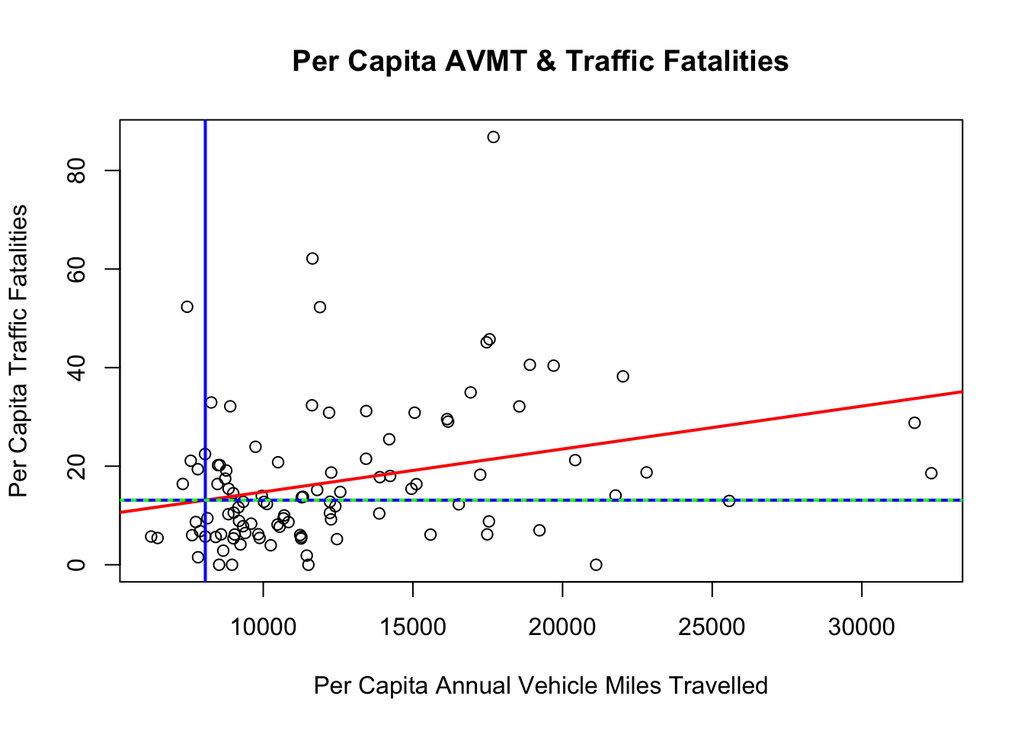

```r
abline(h = 13.10732, col="blue", lwd=2) #show mean

#can combine if we're feeling fancy
abline(h=(mean(model2$fitted.values[which(traffic2019$percapavmt==0.008063393)])), col="green", lwd=2, lty=3)
```

```r
#or if not just plug it into our equation
6.088 + 870.564*0.008063393
```

```
## [1] 13.1077
```

#### Your next challenge

Rerun your analysis for a different year(don’t forget about find and replace). How do the results change? *bonus if you’re bored: add county label to each point

Other regression commands you may find useful:

```r
coef(model1) #coefficients
```

```
## (Intercept)  percapavmt
##    6.087623  870.563844
```

```r
confint(model1) #confidence intervals
```

```
##                  2.5 %    97.5 %
## (Intercept)  -1.205952   13.3812
## percapavmt  325.569688 1415.5580
```

```r
resid(model1) #residuals
```

```
##           1           2           3           4           5           6
## -11.3688720  65.3002722  -2.8402338 -14.1909272 -13.8858804  -8.2216445
##           7           8           9          10          11          12
##   8.4170987  -0.7693293  19.6499040 -10.7672936  -8.4572157 -15.3943727
##          13          14          15          16          17          18
##  -1.1919629 -10.5688609 -11.0603245  -5.8050355  -8.5707352 -15.6485609
##          19          20          21          22          23          24
##  -7.3874245  -3.9446134  -3.6920524 -10.0123780  -2.4165383 -16.1069377
##          25          26          27          28          29          30
##  12.9700668 -10.9790483  14.1532388  13.4059266   3.7850760  45.9127068
##          31          32          33          34          35          36
##   1.6360618   7.0062276  -2.5796007 -10.2551222  39.7621318  23.8492193
##          37          38          39          40          41          42
##  -2.8922305  18.0215030   6.4937990  -7.7614574  -2.6375284  18.3166809
##          43          44          45          46          47          48
##  -5.9647702 -24.4752997  -6.7146635   2.9214187  -6.2925178  -9.8307699
##          49          50          51          52          53          54
##  -7.3929435  -7.5623697  -2.0581569 -12.5592603  11.6608659 -15.8401642
##          55          56          57          58          59          60
##   6.7358243  -6.1327905  -7.0462886  -3.3581906  -5.1847336  -2.2246945
##          61          62          63          64          65          66
##   3.7195076  14.1455069   9.3567492   8.8745248   3.9465861 -13.5102007
##          67          68          69          70          71          72
##  -6.8664360  24.3768391   5.5727081  -2.1567128  -0.4130515  -7.8246174
##          73          74          75          76          77          78
##   5.4066971 -13.5399288   9.8900380   9.3719628  -7.1991316  35.8303863
##          79          80          81          82          83          84
##  -3.7297842  -7.8222650  -7.7720738  -5.3896050  -1.4402973  -7.5649069
##          85          86          87          88          89          90
##  -2.2576168  17.1569399  16.1457557   1.9500977   6.6966328  -6.0956802
##          91          92          93          94          95          96
##  -0.4684993   0.6005651  -4.1518956  -5.0165451  -4.9337725 -15.1399754
##          97          98          99         100         101         102
##   9.4074860  -9.2498691  -6.3881804  -6.2201776  -3.5151830 -11.7368051
```

```r
deviance(model1) #residual sum of squares
```

```
## [1] 18946.13
```

More Bonus code: GGplot versions of above

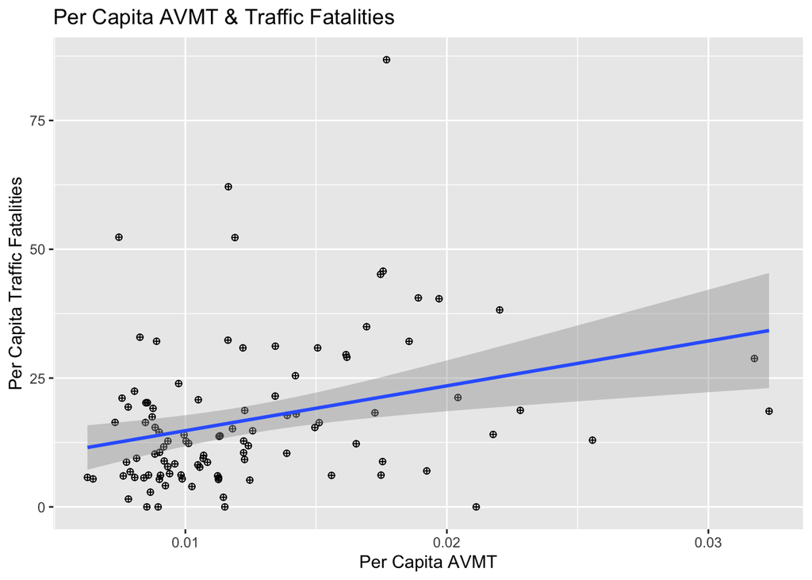

```r
p <- ggplot(traffic2019, aes(x = percapavmt, y = percapdeaths))+   #using ggplot and dataset
 geom_point(shape=10) + #basic scatter plot
  geom_smooth(method = "lm")+
  labs(title="Per Capita AVMT & Traffic Fatalities")+ xlab("Per Capita AVMT")+ ylab("Per Capita Traffic Fatalities")
p
```

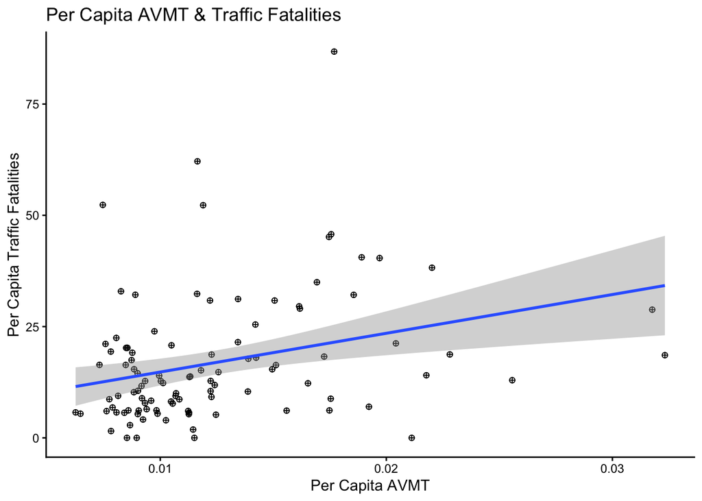

```r
p + theme_classic()
```

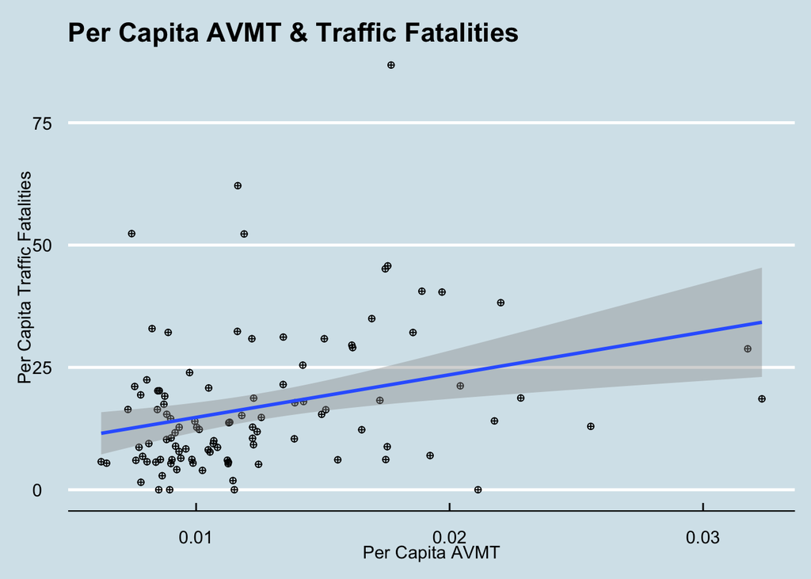

```r
#install.packages("ggthemes") #https://yutannihilation.github.io/allYourFigureAreBelongToUs/ggthemes/
library("ggthemes")
p + theme_economist()
```

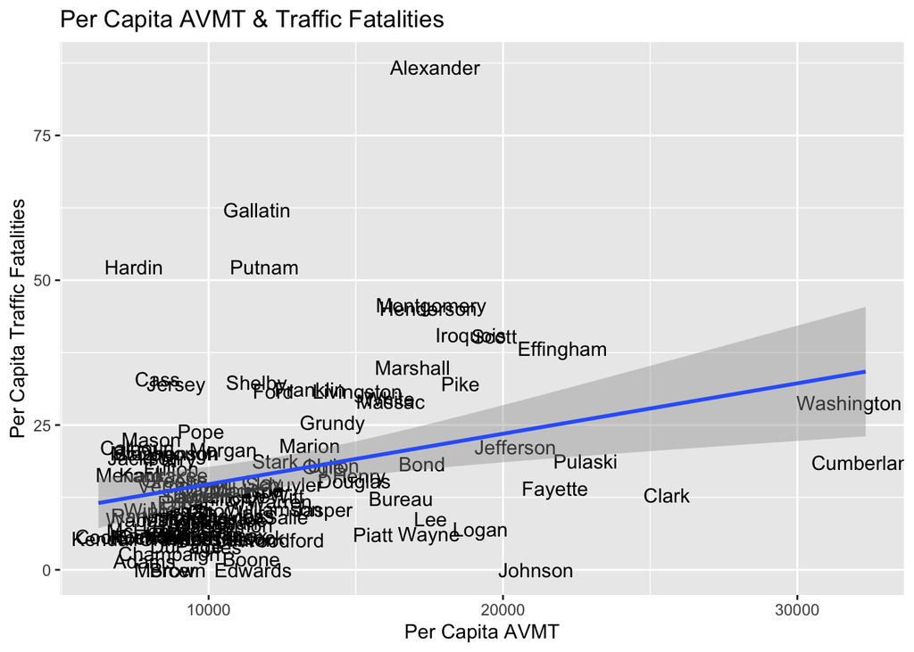

```r
#Show County Names
ggplot(traffic2019, aes(x = (percapavmt*1000000), y = percapdeaths, label = county))+   #using ggplot and dataset
 geom_text() + # Change the geom type
  geom_smooth(method = "lm")+
  labs(title="Per Capita AVMT & Traffic Fatalities") + xlab("Per Capita AVMT") + ylab("Per Capita Traffic Fatalities")
```

```r
#Messy!!!


#Just label dekalb
traffic2019$dekalb <- ifelse(traffic2019$county=="DeKalb", "DeKalb", "")  # Pick county you want to have labeled & specify how you want it labeled)
table(traffic2019$dekalb)
```

```
##
##        DeKalb
##    101      1
```

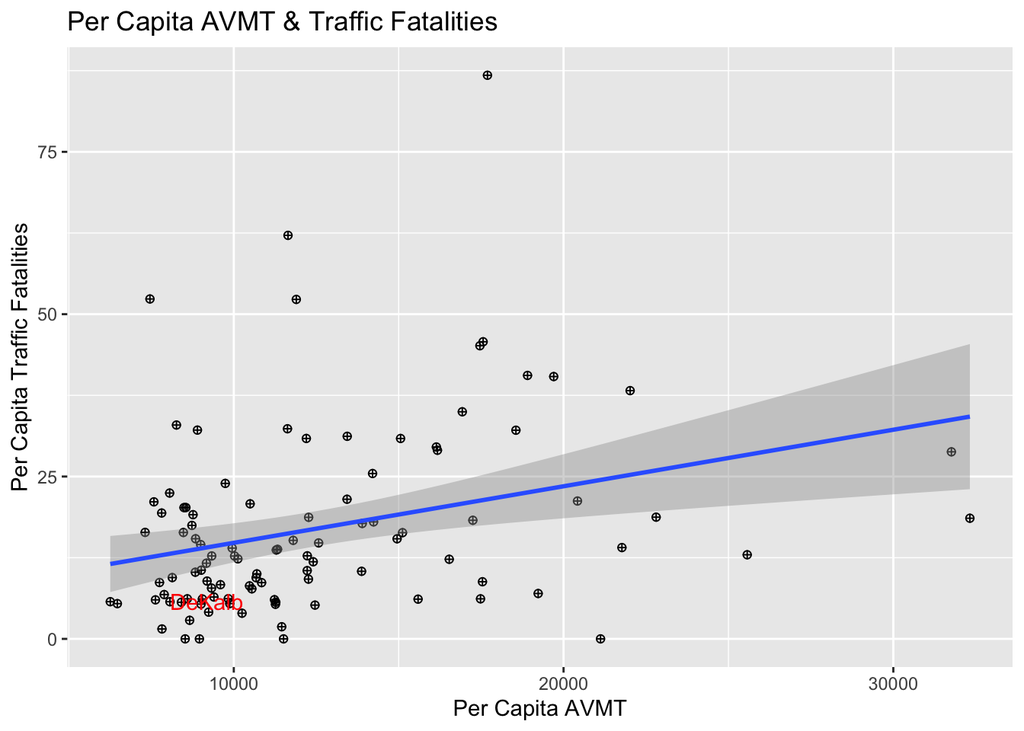

```r
w <- ggplot(traffic2019, aes(x = (percapavmt*1000000), y = percapdeaths, label = dekalb))+
  geom_point(shape = 10) +
  geom_text(hjust = -.001, nudge_x = 0.0005, color = "red") +
  geom_smooth(method = "lm")+
  labs(title="Per Capita AVMT & Traffic Fatalities") + xlab("Per Capita AVMT") + ylab("Per Capita Traffic Fatalities")

w
```

```r
# We're at the bottom left. What does it mean that we're below the regression curve?
```